# W15D6 - Buccarini Giacomo Es6

```python
from sqlalchemy import create_engine
import dotenv
import os
import pandas as pd
dotenv.load_dotenv(override=True)
username = os.getenv('username')
password = os.getenv('password')
host = os.getenv('host')
dbname = os.getenv('dbname')

import pandas as pd
dbname = "AdventureWorksDW"
conn_string = f"mysql+pymysql://{username}:{password}@{host}/{dbname}"
db_engine = create_engine(conn_string)
query = """SELECT *
        FROM dimproduct
        """
df = pd.read_sql(query, db_engine)
```

Esercizio Dal database AdventureWorks estraiamo la tabella dimproduct 1 • Sulla colonna DealerPrice, utilizzando il metodo .round(), arrotondiamo i valori alle due cifre decimali, e poi al valore intero più vicino 2 • Utilizzando il metodo .clip(), facciamo in modo che i valori siano compresi tra un minimo di 0 e un massimo di 1000

```python
df.DealerPrice.round()  #1
```

```
0        NaN
1        NaN
2        NaN
3        NaN
4        NaN
       ...
601     61.0
602     73.0
603    324.0
604    324.0
605    324.0
Name: DealerPrice, Length: 606, dtype: float64
```

```python
df.DealerPrice.round(2) #1
```

```
0         NaN
1         NaN
2         NaN
3         NaN
4         NaN
        ...
601     60.74
602     72.89
603    323.99
604    323.99
605    323.99
Name: DealerPrice, Length: 606, dtype: float64
```

```python
clipper_price = df.DealerPrice.clip(lower=0,upper=1000) #2
clipper_price.describe()
```

```
count     395.000000
mean      381.464559
std       351.660330
min         1.374000
25%        41.994000
50%       218.454000
75%       722.594900
max      1000.000000
Name: DealerPrice, dtype: float64
```

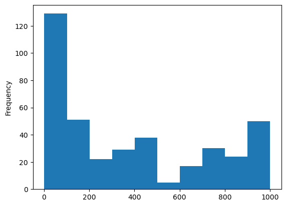

```python
clipper_price.plot(kind="hist")
```

Esercizio Creiamo un DataFrame sintetico, che contiene i guadagni mensili di diverse annate, con il seguente codice: years = 5 a = pd.DataFrame({"Mese": list("GFMAMGLASOND"years),  
"Anno": np.repeat(list(range(years)), 12),  
"Guadagni": np.random.randint(800, 5000, 12years)})

3 • Calcola la somma cumulativa delle vendite per ogni mese utilizzando il metodo .cumsum() 4 • Come sopra, ma diviso per ogni anno

```python
import numpy as np
years = 5
guadagni = pd.DataFrame({"Mese": list("GFMAMGLASOND"*years),
                    "Anno": np.repeat(list(range(years)), 12),
                    "Guadagni": np.random.randint(800, 5000, 12*years)})
```

```python
guadagni
```

|  | Mese | Anno | Guadagni |
| --- | --- | --- | --- |
| 0 | G | 0 | 2941 |
| 1 | F | 0 | 2135 |
| 2 | M | 0 | 4001 |
| 3 | A | 0 | 994 |
| 4 | M | 0 | 1194 |
| 5 | G | 0 | 1979 |
| 6 | L | 0 | 1649 |
| 7 | A | 0 | 1545 |
| 8 | S | 0 | 2954 |
| 9 | O | 0 | 4340 |
| 10 | N | 0 | 3066 |
| 11 | D | 0 | 3252 |
| 12 | G | 1 | 4569 |
| 13 | F | 1 | 1731 |
| 14 | M | 1 | 3886 |
| 15 | A | 1 | 1751 |
| 16 | M | 1 | 1719 |
| 17 | G | 1 | 2347 |
| 18 | L | 1 | 1113 |
| 19 | A | 1 | 3941 |
| 20 | S | 1 | 809 |
| 21 | O | 1 | 1137 |
| 22 | N | 1 | 4834 |
| 23 | D | 1 | 1161 |
| 24 | G | 2 | 1256 |
| 25 | F | 2 | 1214 |
| 26 | M | 2 | 4216 |
| 27 | A | 2 | 4006 |
| 28 | M | 2 | 926 |
| 29 | G | 2 | 820 |
| 30 | L | 2 | 3006 |
| 31 | A | 2 | 2971 |
| 32 | S | 2 | 2128 |
| 33 | O | 2 | 3806 |
| 34 | N | 2 | 1595 |
| 35 | D | 2 | 3374 |
| 36 | G | 3 | 3549 |
| 37 | F | 3 | 1784 |
| 38 | M | 3 | 1084 |
| 39 | A | 3 | 3348 |
| 40 | M | 3 | 4420 |
| 41 | G | 3 | 4074 |
| 42 | L | 3 | 2104 |
| 43 | A | 3 | 924 |
| 44 | S | 3 | 2526 |
| 45 | O | 3 | 3937 |
| 46 | N | 3 | 4640 |
| 47 | D | 3 | 3098 |
| 48 | G | 4 | 4793 |
| 49 | F | 4 | 1877 |
| 50 | M | 4 | 4934 |
| 51 | A | 4 | 4623 |
| 52 | M | 4 | 4466 |
| 53 | G | 4 | 2426 |
| 54 | L | 4 | 3745 |
| 55 | A | 4 | 2170 |
| 56 | S | 4 | 2914 |
| 57 | O | 4 | 4083 |
| 58 | N | 4 | 3958 |
| 59 | D | 4 | 3726 |

```python
guadagni.Guadagni.cumsum()  #3
```

```
0       2941
1       5076
2       9077
3      10071
4      11265
5      13244
6      14893
7      16438
8      19392
9      23732
10     26798
11     30050
12     34619
13     36350
14     40236
```

[output cut: 46 more lines]

```python
guadagni["CumulativaAnnuale"] = guadagni.groupby("Anno").Guadagni.cumsum() #4
```

```python
guadagni["CumulativaTotale"] = guadagni.Guadagni.cumsum() #4
```

```python
guadagni
```

|  | Mese | Anno | Guadagni | CumulativaAnnuale | CumulativaTotale |
| --- | --- | --- | --- | --- | --- |
| 0 | G | 0 | 2941 | 2941 | 2941 |
| 1 | F | 0 | 2135 | 5076 | 5076 |
| 2 | M | 0 | 4001 | 9077 | 9077 |
| 3 | A | 0 | 994 | 10071 | 10071 |
| 4 | M | 0 | 1194 | 11265 | 11265 |
| 5 | G | 0 | 1979 | 13244 | 13244 |
| 6 | L | 0 | 1649 | 14893 | 14893 |
| 7 | A | 0 | 1545 | 16438 | 16438 |
| 8 | S | 0 | 2954 | 19392 | 19392 |
| 9 | O | 0 | 4340 | 23732 | 23732 |
| 10 | N | 0 | 3066 | 26798 | 26798 |
| 11 | D | 0 | 3252 | 30050 | 30050 |
| 12 | G | 1 | 4569 | 4569 | 34619 |
| 13 | F | 1 | 1731 | 6300 | 36350 |
| 14 | M | 1 | 3886 | 10186 | 40236 |
| 15 | A | 1 | 1751 | 11937 | 41987 |
| 16 | M | 1 | 1719 | 13656 | 43706 |
| 17 | G | 1 | 2347 | 16003 | 46053 |
| 18 | L | 1 | 1113 | 17116 | 47166 |
| 19 | A | 1 | 3941 | 21057 | 51107 |
| 20 | S | 1 | 809 | 21866 | 51916 |
| 21 | O | 1 | 1137 | 23003 | 53053 |
| 22 | N | 1 | 4834 | 27837 | 57887 |
| 23 | D | 1 | 1161 | 28998 | 59048 |
| 24 | G | 2 | 1256 | 1256 | 60304 |
| 25 | F | 2 | 1214 | 2470 | 61518 |
| 26 | M | 2 | 4216 | 6686 | 65734 |
| 27 | A | 2 | 4006 | 10692 | 69740 |
| 28 | M | 2 | 926 | 11618 | 70666 |
| 29 | G | 2 | 820 | 12438 | 71486 |
| 30 | L | 2 | 3006 | 15444 | 74492 |
| 31 | A | 2 | 2971 | 18415 | 77463 |
| 32 | S | 2 | 2128 | 20543 | 79591 |
| 33 | O | 2 | 3806 | 24349 | 83397 |
| 34 | N | 2 | 1595 | 25944 | 84992 |
| 35 | D | 2 | 3374 | 29318 | 88366 |
| 36 | G | 3 | 3549 | 3549 | 91915 |
| 37 | F | 3 | 1784 | 5333 | 93699 |
| 38 | M | 3 | 1084 | 6417 | 94783 |
| 39 | A | 3 | 3348 | 9765 | 98131 |
| 40 | M | 3 | 4420 | 14185 | 102551 |
| 41 | G | 3 | 4074 | 18259 | 106625 |
| 42 | L | 3 | 2104 | 20363 | 108729 |
| 43 | A | 3 | 924 | 21287 | 109653 |
| 44 | S | 3 | 2526 | 23813 | 112179 |
| 45 | O | 3 | 3937 | 27750 | 116116 |
| 46 | N | 3 | 4640 | 32390 | 120756 |
| 47 | D | 3 | 3098 | 35488 | 123854 |
| 48 | G | 4 | 4793 | 4793 | 128647 |
| 49 | F | 4 | 1877 | 6670 | 130524 |
| 50 | M | 4 | 4934 | 11604 | 135458 |
| 51 | A | 4 | 4623 | 16227 | 140081 |
| 52 | M | 4 | 4466 | 20693 | 144547 |
| 53 | G | 4 | 2426 | 23119 | 146973 |
| 54 | L | 4 | 3745 | 26864 | 150718 |
| 55 | A | 4 | 2170 | 29034 | 152888 |
| 56 | S | 4 | 2914 | 31948 | 155802 |
| 57 | O | 4 | 4083 | 36031 | 159885 |
| 58 | N | 4 | 3958 | 39989 | 163843 |
| 59 | D | 4 | 3726 | 43715 | 167569 |

```python
guadagni.Guadagni.sum()
```

```
167569
```

Esercizio 1/2 Dal database AdventureWorks estraiamo la tabella dimcustomer 5 • Trasformiamo i nomi dei clienti in modo che abbiano solo lettere minuscole, e i cognomi in modo che abbiano solo lettere maiuscole 6 • Sulla colonna EmailAddress, utilizzando il metodo .str.split(), estraiamo nome utente e dominio 7 • Sulla colonna Phone, estraiamo ogni parte del numero (ad es. da "1 (11) 500 555-0162" a ["1", "(11)", "500", "555-0162"]) 8 • Utilizzando il metodo .str.contains(), estraiamo tutti gli indirizzi e-mail che contengono il numero "21"

Esercizio 2/2 9 • Estraiamo tutti gli indirizzi e-mail che contengono il numero "20" oppure il numero "10" 10 • Calcolare la lunghezza di ogni indirizzo e-mail ed estrarre i dieci più lunghi e i dieci più corti 11 • Modificare il dominio degli indirizzi e-mail da "adventure-works.com" a "aw-db.com" mediante il metodo .str.replace() 12 • Dalla colonna AddressLine1 estraiamo tutti gli indirizzi che contengono la sottostringa "Street"

dbname = "AdventureWorksDW" conn_string = f"mysql+pymysql://{username}:{password}@{host}/{dbname}" db_engine = create_engine(conn_string) query = """SELECT * FROM dimcustomer """ dc = pd.read_sql(query, db_engine)

```python
#5
dc.FirstName = dc.FirstName.str.lower()
dc.LastName = dc.LastName.str.upper()
dc
```

|  | CustomerKey | GeographyKey | CustomerAlternateKey | Title | FirstName | MiddleName | LastName | NameStyle | BirthDate | MaritalStatus | ... | EnglishOccupation | SpanishOccupation | FrenchOccupation | HouseOwnerFlag | NumberCarsOwned | AddressLine1 | AddressLine2 | Phone | DateFirstPurchase | CommuteDistance |
| --- | --- | --- | --- | --- | --- | --- | --- | --- | --- | --- | --- | --- | --- | --- | --- | --- | --- | --- | --- | --- | --- |
| 0 | 11000 | 26 | AW00011000 | None | jon | V | YANG | 0 | 1971-10-06 | M | ... | Professional | Profesional | Cadre | 1 | 0 | 3761 N. 14th St | None | 1 (11) 500 555-0162 | 2011-01-19 | 1-2 Miles |
| 1 | 11001 | 37 | AW00011001 | None | eugene | L | HUANG | 0 | 1976-05-10 | S | ... | Professional | Profesional | Cadre | 0 | 1 | 2243 W St. | None | 1 (11) 500 555-0110 | 2011-01-15 | 0-1 Miles |
| 2 | 11002 | 31 | AW00011002 | None | ruben | None | TORRES | 0 | 1971-02-09 | M | ... | Professional | Profesional | Cadre | 1 | 1 | 5844 Linden Land | None | 1 (11) 500 555-0184 | 2011-01-07 | 2-5 Miles |
| 3 | 11003 | 11 | AW00011003 | None | christy | None | ZHU | 0 | 1973-08-14 | S | ... | Professional | Profesional | Cadre | 0 | 1 | 1825 Village Pl. | None | 1 (11) 500 555-0162 | 2010-12-29 | 5-10 Miles |
| 4 | 11004 | 19 | AW00011004 | None | elizabeth | None | JOHNSON | 0 | 1979-08-05 | S | ... | Professional | Profesional | Cadre | 1 | 4 | 7553 Harness Circle | None | 1 (11) 500 555-0131 | 2011-01-23 | 1-2 Miles |
| ... | ... | ... | ... | ... | ... | ... | ... | ... | ... | ... | ... | ... | ... | ... | ... | ... | ... | ... | ... | ... | ... |
| 18479 | 29479 | 209 | AW00029479 | None | tommy | L | TANG | 0 | 1969-06-30 | M | ... | Clerical | Administrativo | Employé | 1 | 0 | 111, rue Maillard | None | 1 (11) 500 555-0136 | 2012-09-04 | 0-1 Miles |
| 18480 | 29480 | 248 | AW00029480 | None | nina | W | RAJI | 0 | 1977-05-06 | S | ... | Clerical | Administrativo | Employé | 1 | 0 | 9 Katherine Drive | None | 1 (11) 500 555-0146 | 2013-07-17 | 0-1 Miles |
| 18481 | 29481 | 120 | AW00029481 | None | ivan | None | SURI | 0 | 1965-07-04 | S | ... | Clerical | Administrativo | Employé | 0 | 0 | Knaackstr 4 | None | 1 (11) 500 555-0144 | 2011-08-13 | 0-1 Miles |
| 18482 | 29482 | 179 | AW00029482 | None | clayton | None | ZHANG | 0 | 1964-09-01 | M | ... | Clerical | Administrativo | Employé | 1 | 0 | 1080, quai de Grenelle | None | 1 (11) 500 555-0137 | 2012-09-18 | 0-1 Miles |
| 18483 | 29483 | 217 | AW00029483 | None | jésus | L | NAVARRO | 0 | 1965-06-06 | M | ... | Clerical | Administrativo | Employé | 1 | 0 | 244, rue de la Centenaire | None | 1 (11) 500 555-0141 | 2012-09-09 | 0-1 Miles |

18484 rows × 29 columns

```python
#6
dc.EmailAddress.str.split("@")
```

[output not shown]

```python
#per contare se tutte le mail sono dello stesso provider
conteggio_provider = dc.EmailAddress.str.contains("adventure-works.com", regex=False)
```

```python
#per contare se tutte le mail sono dello stesso provider
conteggio_provider.value_counts()
```

```
EmailAddress
True    18484
Name: count, dtype: int64
```

```python
#7
dc.Phone.str.split(" ")
```

```
0        [1, (11), 500, 555-0162]
1        [1, (11), 500, 555-0110]
2        [1, (11), 500, 555-0184]
3        [1, (11), 500, 555-0162]
4        [1, (11), 500, 555-0131]
                   ...
18479    [1, (11), 500, 555-0136]
18480    [1, (11), 500, 555-0146]
18481    [1, (11), 500, 555-0144]
18482    [1, (11), 500, 555-0137]
18483    [1, (11), 500, 555-0141]
Name: Phone, Length: 18484, dtype: object
```

```python
dc.Phone.str.extract("(^[0-9])") #regex I
```

|  | 0 |
| --- | --- |
| 0 | 1 |
| 1 | 1 |
| 2 | 1 |
| 3 | 1 |
| 4 | 1 |
| ... | ... |
| 18479 | 1 |
| 18480 | 1 |
| 18481 | 1 |
| 18482 | 1 |
| 18483 | 1 |

18484 rows × 1 columns

```python
dc.Phone.str.extract("(-[0-9]+$)") #regex II
```

|  | 0 |
| --- | --- |
| 0 | -0162 |
| 1 | -0110 |
| 2 | -0184 |
| 3 | -0162 |
| 4 | -0131 |
| ... | ... |
| 18479 | -0136 |
| 18480 | -0146 |
| 18481 | -0144 |
| 18482 | -0137 |
| 18483 | -0141 |

18484 rows × 1 columns

```python
#8
#mail21 = dc.EmailAddress[dc.EmailAddress.str.contains('21')]
#mail21
mail21 = dc["EmailAddress"].str.contains('21')
dc.EmailAddress.loc[mail21]
```

```
64          chase21@adventure-works.com
118         alvin21@adventure-works.com
130      caroline21@adventure-works.com
163       gabriel21@adventure-works.com
203          luis21@adventure-works.com
                      ...
18337      hector21@adventure-works.com
18365      cheryl21@adventure-works.com
18435     stanley21@adventure-works.com
18440      rafael21@adventure-works.com
18480        nina21@adventure-works.com
Name: EmailAddress, Length: 431, dtype: object
```

```python
#9
#mail20_10 = dc.EmailAddress[(dc.EmailAddress.str.contains('20')) | (dc.EmailAddress.str.contains('10'))]
#mail20_10

mail20_10 = (dc['EmailAddress'].str.contains('20') | dc['EmailAddress'].str.contains('10'))
dc.EmailAddress.loc[mail20_10]
```

```
1            eugene10@adventure-works.com
10        jacquelyn20@adventure-works.com
22            ethan20@adventure-works.com
30          bethany10@adventure-works.com
32           denise10@adventure-works.com
                       ...
18395         lydia10@adventure-works.com
18397        walter10@adventure-works.com
18415         oscar20@adventure-works.com
18418       lindsey10@adventure-works.com
18428    kristopher20@adventure-works.com
Name: EmailAddress, Length: 1042, dtype: object
```

```python
#10
lunghezza = dc.EmailAddress.apply(len) #calcolare la lughezza degli indirizzi mail
sorted(lunghezza)[-10:]
```

```
[33, 33, 33, 33, 33, 33, 33, 33, 33, 33]
```

```python
#10
#filtro_lunghezze = (lunghezza <= 24) | (lunghezza == 33)
#dc.EmailAddress.loc[filtro_lunghezze]
filtro_corti = (lunghezza <= 24)
filtro_lunghi = (lunghezza == 33)
dc.EmailAddress.loc[filtro_corti].iloc[-10:]
dc.EmailAddress.loc[filtro_lunghi].iloc[-10:]
```

```
9242     christopher11@adventure-works.com
10233    christopher24@adventure-works.com
12090    christopher22@adventure-works.com
13417    christopher14@adventure-works.com
14171    christopher20@adventure-works.com
14964    christopher26@adventure-works.com
15049    christopher13@adventure-works.com
16661    christopher17@adventure-works.com
16808    christopher19@adventure-works.com
17017    christopher15@adventure-works.com
Name: EmailAddress, dtype: object
```

```python
lunghezze_ord = lunghezza.sort_values() #alternativa
```

```python
indici_corti = lunghezze_ord.iloc[:10].index #alternativa
```

```python
dc.EmailAddress.loc[indici_corti]  #alternativa
```

```
3974       k0@adventure-works.com
15299      y0@adventure-works.com
1658     joy2@adventure-works.com
550      deb4@adventure-works.com
13888    roy9@adventure-works.com
6264     ian1@adventure-works.com
2326     bob8@adventure-works.com
13825    zoe3@adventure-works.com
215      ana7@adventure-works.com
11213    jay9@adventure-works.com
Name: EmailAddress, dtype: object
```

```python
# 11
dc.EmailAddress.str.replace("adventure-works.com","aw-db.com")
```

```
0             jon24@aw-db.com
1          eugene10@aw-db.com
2           ruben35@aw-db.com
3         christy12@aw-db.com
4        elizabeth5@aw-db.com
                 ...
18479        tommy2@aw-db.com
18480        nina21@aw-db.com
18481         ivan0@aw-db.com
18482      clayton0@aw-db.com
18483        jésus9@aw-db.com
Name: EmailAddress, Length: 18484, dtype: object
```

```python
#12AddressLine1
Add_street = dc.AddressLine1.str.contains('Street')
dc.AddressLine1.loc[Add_street]
```

```
7              942 Brook Street
12            4785 Scott Street
32           626 Bentley Street
63           4927 Virgil Street
125          8481 Zartop Street
                  ...
18273        2155 Zartop Street
18292         3931 Scott Street
18323    134 Peachwillow Street
18333       1023 Hawkins Street
18351          8618 Rose Street
Name: AddressLine1, Length: 512, dtype: object
```

Esercizio 1/2 Dai beginner_datasets carichiamo in un DataFrame il file facebook.csv, che contiene dei post con data di pubblicazione, tipo (foto, video, …) e numero di reactions raccolte: 13 • Con la funzione pd.to_datetime() convertiamo la colonna status_published in formato Timestamp 14 • Utilizzando il metodo .df.strftime(), formatta le date delle pubblicazioni in un formato specifico (ad esempio, "%Y-%m-%d %H:%M:%S"). 15 • Utilizzando gli attributi .dt.year , .dt.month , .dt.day , .dt.dayofweek , .dt.dayofyear, ottieniamo informazioni specifiche sulle date delle transazioni, come l'anno, il mese, il giorno della settimana, il giorno dell'anno, ecc. Esercizio 2/2 16 • Estraiamo solo i post relativi al 2012 17 • Estraiamo solo i post relativi a maggio 2018 18 • Confrontiamo il numero di post pubblicati nei weekend rispetto al numero di post pubblicati nel resto della settimana 19 • Troviamo il primo e ultimo post pubblicati in ogni anno 20 • Utilizzando il metodo .tz_localize(), aggiungiamo un fuso orario alle date delle transazioni 21 • Calcoliamo la differenza di tempo tra due transazioni 22 • Quanti tipi di post ci sono? E quanti per ogni tipo?

```python
fb = pd.read_csv("facebook.csv")
fb
```

|  | status_id | status_type | status_published | num_reactions | num_comments | num_shares | num_likes | num_loves | num_wows | num_hahas | num_sads | num_angrys |
| --- | --- | --- | --- | --- | --- | --- | --- | --- | --- | --- | --- | --- |
| 0 | 246675545449582_1649696485147474 | video | 4/22/2018 6:00 | 529 | 512 | 262 | 432 | 92 | 3 | 1 | 1 | 0 |
| 1 | 246675545449582_1649426988507757 | photo | 4/21/2018 22:45 | 150 | 0 | 0 | 150 | 0 | 0 | 0 | 0 | 0 |
| 2 | 246675545449582_1648730588577397 | video | 4/21/2018 6:17 | 227 | 236 | 57 | 204 | 21 | 1 | 1 | 0 | 0 |
| 3 | 246675545449582_1648576705259452 | photo | 4/21/2018 2:29 | 111 | 0 | 0 | 111 | 0 | 0 | 0 | 0 | 0 |
| 4 | 246675545449582_1645700502213739 | photo | 4/18/2018 3:22 | 213 | 0 | 0 | 204 | 9 | 0 | 0 | 0 | 0 |
| ... | ... | ... | ... | ... | ... | ... | ... | ... | ... | ... | ... | ... |
| 7045 | 1050855161656896_1061863470556065 | photo | 9/24/2016 2:58 | 89 | 0 | 0 | 89 | 0 | 0 | 0 | 0 | 0 |
| 7046 | 1050855161656896_1061334757275603 | photo | 9/23/2016 11:19 | 16 | 0 | 0 | 14 | 1 | 0 | 1 | 0 | 0 |
| 7047 | 1050855161656896_1060126464063099 | photo | 9/21/2016 23:03 | 2 | 0 | 0 | 1 | 1 | 0 | 0 | 0 | 0 |
| 7048 | 1050855161656896_1058663487542730 | photo | 9/20/2016 0:43 | 351 | 12 | 22 | 349 | 2 | 0 | 0 | 0 | 0 |
| 7049 | 1050855161656896_1050858841656528 | photo | 9/10/2016 10:30 | 17 | 0 | 0 | 17 | 0 | 0 | 0 | 0 | 0 |

7050 rows × 12 columns

```python
#13
fb.status_published = pd.to_datetime(fb.status_published)
fb.dtypes
```

```
status_id                   object
status_type                 object
status_published    datetime64[ns]
num_reactions                int64
num_comments                 int64
num_shares                   int64
num_likes                    int64
num_loves                    int64
num_wows                     int64
num_hahas                    int64
num_sads                     int64
num_angrys                   int64
dtype: object
```

```python
#14
fb.status_published.dt.strftime("%Y-%m-%d %H:%M:%S")
```

```
0       2018-04-22 06:00:00
1       2018-04-21 22:45:00
2       2018-04-21 06:17:00
3       2018-04-21 02:29:00
4       2018-04-18 03:22:00
               ...
7045    2016-09-24 02:58:00
7046    2016-09-23 11:19:00
7047    2016-09-21 23:03:00
7048    2016-09-20 00:43:00
7049    2016-09-10 10:30:00
Name: status_published, Length: 7050, dtype: object
```

```python
#15
fb.status_published.dt.year  #anno
fb.status_published.dt.month  #mese
fb.status_published.dt.day #giorno
fb.status_published.dt.dayofweek
fb.status_published.dt.dayofyear
```

```
0       112
1       111
2       111
3       111
4       108
       ...
7045    268
7046    267
7047    265
7048    264
7049    254
Name: status_published, Length: 7050, dtype: int32
```

```python
#16
filtro2012 = fb.status_published.dt.year == 2012
fb.loc[filtro2012]
```

|  | status_id | status_type | status_published | num_reactions | num_comments | num_shares | num_likes | num_loves | num_wows | num_hahas | num_sads | num_angrys |
| --- | --- | --- | --- | --- | --- | --- | --- | --- | --- | --- | --- | --- |
| 2046 | 246675545449582_303160673134402 | photo | 2012-12-23 03:11:00 | 0 | 0 | 0 | 0 | 0 | 0 | 0 | 0 | 0 |
| 2047 | 246675545449582_302341609882975 | photo | 2012-12-21 06:02:00 | 4 | 1 | 0 | 4 | 0 | 0 | 0 | 0 | 0 |
| 2048 | 246675545449582_299212316862571 | photo | 2012-12-13 11:36:00 | 3 | 0 | 0 | 3 | 0 | 0 | 0 | 0 | 0 |
| 2049 | 246675545449582_290159194434550 | photo | 2012-11-18 09:50:00 | 5 | 1 | 1 | 5 | 0 | 0 | 0 | 0 | 0 |
| 2050 | 246675545449582_290154177768385 | photo | 2012-11-18 09:16:00 | 2 | 0 | 0 | 2 | 0 | 0 | 0 | 0 | 0 |
| ... | ... | ... | ... | ... | ... | ... | ... | ... | ... | ... | ... | ... |
| 2630 | 246675545449582_246688625448274 | photo | 2012-07-15 03:54:00 | 19 | 17 | 3 | 19 | 0 | 0 | 0 | 0 | 0 |
| 2631 | 246675545449582_246686478781822 | photo | 2012-07-15 03:42:00 | 12 | 3 | 0 | 12 | 0 | 0 | 0 | 0 | 0 |
| 2632 | 246675545449582_246684432115360 | photo | 2012-07-15 03:32:00 | 14 | 1 | 0 | 14 | 0 | 0 | 0 | 0 | 0 |
| 2633 | 246675545449582_246678538782616 | photo | 2012-07-15 02:58:00 | 14 | 7 | 0 | 14 | 0 | 0 | 0 | 0 | 0 |
| 2634 | 246675545449582_246677465449390 | photo | 2012-07-15 02:51:00 | 15 | 3 | 0 | 15 | 0 | 0 | 0 | 0 | 0 |

589 rows × 12 columns

```python
#17
filtro2018 = fb.status_published.dt.year == 2018
filtromay = fb.status_published.dt.month == 5
fil18May = filtro2018 & filtromay
fb.loc[fil18May]
```

|  | status_id | status_type | status_published | num_reactions | num_comments | num_shares | num_likes | num_loves | num_wows | num_hahas | num_sads | num_angrys |
| --- | --- | --- | --- | --- | --- | --- | --- | --- | --- | --- | --- | --- |
| 2690 | 134115277150304_264554297439734 | photo | 2018-05-31 12:17:00 | 11 | 0 | 0 | 10 | 0 | 1 | 0 | 0 | 0 |
| 2691 | 134115277150304_264493694112461 | photo | 2018-05-31 08:37:00 | 56 | 4 | 2 | 55 | 1 | 0 | 0 | 0 | 0 |
| 2692 | 134115277150304_264416247453539 | photo | 2018-05-31 03:12:00 | 72 | 13 | 1 | 69 | 3 | 0 | 0 | 0 | 0 |
| 2693 | 134115277150304_264168277478336 | photo | 2018-05-30 08:46:00 | 10 | 0 | 0 | 10 | 0 | 0 | 0 | 0 | 0 |
| 2694 | 134115277150304_264160757479088 | photo | 2018-05-30 08:24:00 | 56 | 3 | 12 | 54 | 2 | 0 | 0 | 0 | 0 |
| ... | ... | ... | ... | ... | ... | ... | ... | ... | ... | ... | ... | ... |
| 6339 | 1050855161656896_1615666458509094 | link | 2018-05-04 01:27:00 | 12 | 7 | 7 | 12 | 0 | 0 | 0 | 0 | 0 |
| 6340 | 1050855161656896_1614717551937318 | photo | 2018-05-03 01:15:00 | 63 | 21 | 1 | 62 | 1 | 0 | 0 | 0 | 0 |
| 6341 | 1050855161656896_1614187798656960 | photo | 2018-05-02 12:17:00 | 218 | 105 | 153 | 212 | 2 | 4 | 0 | 0 | 0 |
| 6342 | 1050855161656896_1613063202102753 | video | 2018-05-01 08:38:00 | 246 | 2373 | 475 | 108 | 130 | 5 | 2 | 1 | 0 |
| 6343 | 1050855161656896_1612778858797854 | photo | 2018-05-01 01:18:00 | 34 | 5 | 0 | 33 | 1 | 0 | 0 | 0 | 0 |

595 rows × 12 columns

```python
#18
filtro_we = (fb.status_published.dt.dayofweek == 5) | (fb.status_published.dt.dayofweek == 6)
filtro_we.value_counts()
```

```
status_published
False    5009
True     2041
Name: count, dtype: int64
```

```python
#19
fb2012 = fb.loc[fb.status_published.dt.year == 2012]
fb2012.status_published.max()#'2012-12-23 03:11:00'
fb2012.status_published.min()#'2012-07-15 02:51:00'
```

[output not shown]

```python
#20
fb.status_published.dt.tz_localize()
```

[output not shown]

```python
#21
date1 = fb.status_published.loc[0]
date2 = fb.status_published.loc[10]
date1 - date2
```

```
Timedelta('12 days 04:59:00')
```

```python
date1, date2
```

```
(Timestamp('2018-04-22 06:00:00'), Timestamp('2018-04-10 01:01:00'))
```

```python
#22
fb.status_type.unique()
fb.status_type.value_counts()
```

```
status_type
photo     4288
video     2334
status     365
link        63
Name: count, dtype: int64
```

Esercizio Dai beginner_dataset carichiamo in un DataFrame il file pokemon.csv: 23 • Tramite i metodi .isnull()/.isna() e .sum() controlliamo se ci sono valori nulli nel dataset e contiamo quanti valori nulli ci sono in ogni colonna 24 • Ci sono valori nulli? SI 25 • Se sì, avrebbe senso cercare di riempirli? Meglio di no perchè riempiendoli andremmo a modificare in modo errato il database. 26 • Eliminiamo le righe che contengono valori nulli

```python
pok = pd.read_csv("pokemon.csv")
pok.sample(8)
```

|  | # | Name | Type 1 | Type 2 | Total | HP | Attack | Defense | Sp. Atk | Sp. Def | Speed | Generation | Legendary |
| --- | --- | --- | --- | --- | --- | --- | --- | --- | --- | --- | --- | --- | --- |
| 448 | 403 | Shinx | Electric | NaN | 263 | 45 | 65 | 34 | 40 | 34 | 45 | 4 | False |
| 567 | 508 | Stoutland | Normal | NaN | 500 | 85 | 110 | 90 | 45 | 90 | 80 | 5 | False |
| 500 | 450 | Hippowdon | Ground | NaN | 525 | 108 | 112 | 118 | 68 | 72 | 47 | 4 | False |
| 34 | 29 | Nidoran♀ | Poison | NaN | 275 | 55 | 47 | 52 | 40 | 40 | 41 | 1 | False |
| 634 | 573 | Cinccino | Normal | NaN | 470 | 75 | 95 | 60 | 65 | 60 | 115 | 5 | False |
| 578 | 519 | Pidove | Normal | Flying | 264 | 50 | 55 | 50 | 36 | 30 | 43 | 5 | False |
| 789 | 713 | Avalugg | Ice | NaN | 514 | 95 | 117 | 184 | 44 | 46 | 28 | 6 | False |
| 343 | 314 | Illumise | Bug | NaN | 400 | 65 | 47 | 55 | 73 | 75 | 85 | 3 | False |

```python
#23
pok.isnull().sum()
```

```
#               0
Name            0
Type 1          0
Type 2        386
Total           0
HP              0
Attack          0
Defense         0
Sp. Atk         0
Sp. Def         0
Speed           0
Generation      0
Legendary       0
dtype: int64
```

```python
pok.info() #conta valori non nulli impliciti(il contrario di sopra)
```

```
<class 'pandas.core.frame.DataFrame'>
RangeIndex: 800 entries, 0 to 799
Data columns (total 13 columns):
 #   Column      Non-Null Count  Dtype
---  ------      --------------  -----
 0   #           800 non-null    int64
 1   Name        800 non-null    object
 2   Type 1      800 non-null    object
 3   Type 2      414 non-null    object
 4   Total       800 non-null    int64
 5   HP          800 non-null    int64
 6   Attack      800 non-null    int64
 7   Defense     800 non-null    int64
 8   Sp. Atk     800 non-null    int64
 9   Sp. Def     800 non-null    int64
 10  Speed       800 non-null    int64
 11  Generation  800 non-null    int64
 12  Legendary   800 non-null    bool
dtypes: bool(1), int64(9), object(3)
memory usage: 75.9+ KB
```

```python
#24
pok.head(10) #vedi sopra
```

|  | # | Name | Type 1 | Type 2 | Total | HP | Attack | Defense | Sp. Atk | Sp. Def | Speed | Generation | Legendary |
| --- | --- | --- | --- | --- | --- | --- | --- | --- | --- | --- | --- | --- | --- |
| 0 | 1 | Bulbasaur | Grass | Poison | 318 | 45 | 49 | 49 | 65 | 65 | 45 | 1 | False |
| 1 | 2 | Ivysaur | Grass | Poison | 405 | 60 | 62 | 63 | 80 | 80 | 60 | 1 | False |
| 2 | 3 | Venusaur | Grass | Poison | 525 | 80 | 82 | 83 | 100 | 100 | 80 | 1 | False |
| 3 | 3 | VenusaurMega Venusaur | Grass | Poison | 625 | 80 | 100 | 123 | 122 | 120 | 80 | 1 | False |
| 4 | 4 | Charmander | Fire | NaN | 309 | 39 | 52 | 43 | 60 | 50 | 65 | 1 | False |
| 5 | 5 | Charmeleon | Fire | NaN | 405 | 58 | 64 | 58 | 80 | 65 | 80 | 1 | False |
| 6 | 6 | Charizard | Fire | Flying | 534 | 78 | 84 | 78 | 109 | 85 | 100 | 1 | False |
| 7 | 6 | CharizardMega Charizard X | Fire | Dragon | 634 | 78 | 130 | 111 | 130 | 85 | 100 | 1 | False |
| 8 | 6 | CharizardMega Charizard Y | Fire | Flying | 634 | 78 | 104 | 78 | 159 | 115 | 100 | 1 | False |
| 9 | 7 | Squirtle | Water | NaN | 314 | 44 | 48 | 65 | 50 | 64 | 43 | 1 | False |

```python
#25
```

```python
#26
pok.dropna() # per eliminare riassegnare la colonna
```

|  | # | Name | Type 1 | Type 2 | Total | HP | Attack | Defense | Sp. Atk | Sp. Def | Speed | Generation | Legendary |
| --- | --- | --- | --- | --- | --- | --- | --- | --- | --- | --- | --- | --- | --- |
| 0 | 1 | Bulbasaur | Grass | Poison | 318 | 45 | 49 | 49 | 65 | 65 | 45 | 1 | False |
| 1 | 2 | Ivysaur | Grass | Poison | 405 | 60 | 62 | 63 | 80 | 80 | 60 | 1 | False |
| 2 | 3 | Venusaur | Grass | Poison | 525 | 80 | 82 | 83 | 100 | 100 | 80 | 1 | False |
| 3 | 3 | VenusaurMega Venusaur | Grass | Poison | 625 | 80 | 100 | 123 | 122 | 120 | 80 | 1 | False |
| 6 | 6 | Charizard | Fire | Flying | 534 | 78 | 84 | 78 | 109 | 85 | 100 | 1 | False |
| ... | ... | ... | ... | ... | ... | ... | ... | ... | ... | ... | ... | ... | ... |
| 795 | 719 | Diancie | Rock | Fairy | 600 | 50 | 100 | 150 | 100 | 150 | 50 | 6 | True |
| 796 | 719 | DiancieMega Diancie | Rock | Fairy | 700 | 50 | 160 | 110 | 160 | 110 | 110 | 6 | True |
| 797 | 720 | HoopaHoopa Confined | Psychic | Ghost | 600 | 80 | 110 | 60 | 150 | 130 | 70 | 6 | True |
| 798 | 720 | HoopaHoopa Unbound | Psychic | Dark | 680 | 80 | 160 | 60 | 170 | 130 | 80 | 6 | True |
| 799 | 721 | Volcanion | Fire | Water | 600 | 80 | 110 | 120 | 130 | 90 | 70 | 6 | True |

414 rows × 13 columns

Esercizio Dai beginner_dataset carichiamo in un DataFrame il file automobile.csv: 27 • Ci sono valori nulli? Dove? Quanti? 28 • Quali righe hanno un valore nullo nella colonna num-of-doors? 29 • Esaminando i dati, cerchiamo dei valori da sostituire ai valori nulli nella colonna num-of-doors

```python
auto = pd.read_csv("automobile.csv")
auto.head(5)
```

|  | symboling | normalized-losses | make | fuel-type | aspiration | num-of-doors | body-style | drive-wheels | engine-location | wheel-base | ... | engine-size | fuel-system | bore | stroke | compression-ratio | horsepower | peak-rpm | city-mpg | highway-mpg | price |
| --- | --- | --- | --- | --- | --- | --- | --- | --- | --- | --- | --- | --- | --- | --- | --- | --- | --- | --- | --- | --- | --- |
| 0 | 3 | NaN | alfa-romero | gas | std | two | convertible | rwd | front | 88.6 | ... | 130 | mpfi | 3.47 | 2.68 | 9.0 | 111 | 5000 | 21 | 27 | 13495 |
| 1 | 3 | NaN | alfa-romero | gas | std | two | convertible | rwd | front | 88.6 | ... | 130 | mpfi | 3.47 | 2.68 | 9.0 | 111 | 5000 | 21 | 27 | 16500 |
| 2 | 1 | NaN | alfa-romero | gas | std | two | hatchback | rwd | front | 94.5 | ... | 152 | mpfi | 2.68 | 3.47 | 9.0 | 154 | 5000 | 19 | 26 | 16500 |
| 3 | 2 | 164.0 | audi | gas | std | four | sedan | fwd | front | 99.8 | ... | 109 | mpfi | 3.19 | 3.4 | 10.0 | 102 | 5500 | 24 | 30 | 13950 |
| 4 | 2 | 164.0 | audi | gas | std | four | sedan | 4wd | front | 99.4 | ... | 136 | mpfi | 3.19 | 3.4 | 8.0 | 115 | 5500 | 18 | 22 | 17450 |

5 rows × 26 columns

```python
#27
auto.isnull().sum()
```

```
symboling             0
normalized-losses    37
make                  0
fuel-type             0
aspiration            0
num-of-doors          2
body-style            0
drive-wheels          0
engine-location       0
wheel-base            0
length                0
width                 0
height                0
curb-weight           0
engine-type           0
num-of-cylinders      0
engine-size           0
fuel-system           0
bore                  0
stroke                0
compression-ratio     0
horsepower            0
peak-rpm              0
city-mpg              0
highway-mpg           0
price                 0
dtype: int64
```

```python
#28
doorsna = auto.loc[:,"num-of-doors"].isna()
auto.loc[doorsna].transpose()
```

|  | 26 | 60 |
| --- | --- | --- |
| symboling | 1 | 0 |
| normalized-losses | 148.0 | NaN |
| make | dodge | mazda |
| fuel-type | gas | diesel |
| aspiration | turbo | std |
| num-of-doors | NaN | NaN |
| body-style | sedan | sedan |
| drive-wheels | fwd | fwd |
| engine-location | front | front |
| wheel-base | 93.7 | 98.8 |
| length | 157.3 | 177.8 |
| width | 63.8 | 66.5 |
| height | 50.6 | 55.5 |
| curb-weight | 2191 | 2443 |
| engine-type | ohc | ohc |
| num-of-cylinders | four | four |
| engine-size | 98 | 122 |
| fuel-system | mpfi | idi |
| bore | 3.03 | 3.39 |
| stroke | 3.39 | 3.39 |
| compression-ratio | 7.6 | 22.7 |
| horsepower | 102 | 64 |
| peak-rpm | 5500 | 4650 |
| city-mpg | 24 | 36 |
| highway-mpg | 30 | 42 |
| price | 8558 | 10795 |

```python
#29
auto_group["num-of-doors"].unique()
auto["doors"] = auto["num-of-doors"].replace("two","2")
auto.doors = auto.doors.replace("two", 2)
auto.doors = auto.doors.replace("four", 4)
doors = auto.loc[:,"num-of-doors"].isna()
auto.doors
```

```
0      2
1      2
2      2
3      4
4      4
      ..
197    4
198    4
199    4
200    4
201    4
Name: doors, Length: 202, dtype: object
```

Esercizio Abbiamo il seguente DataFrame che raccoglie le misurazioni di un sensore che misura la temperatura atmosferica giornaliera: import numpy as np import pandas as pd temp = pd.DataFrame({"Giorno": [0, 1, 2, 3, 4, 5, 6,7, 8, 9, 10, 11, 12], "Temperature": [18, 19, 18, np.nan, 21, 20, 20,np.nan, 21, 23, np.nan, 23, 24]}) 30 • Il sensore a volte non funziona, dunque alcuni dati sono mancanti: quale sarebbe la migliore strategia per gestirli?

```python
import numpy as np
import pandas as pd
temp = pd.DataFrame({"Giorno": [0, 1, 2, 3, 4, 5, 6,                               7, 8, 9, 10, 11, 12],       "Temperature": [18, 19, 18, np.nan, 21, 20, 20,                       np.nan, 21, 23, np.nan, 23, 24]})
```

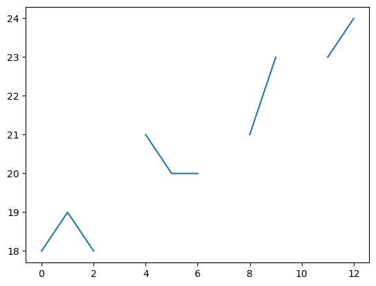

```python
#30
temp.Temperature.plot()
```

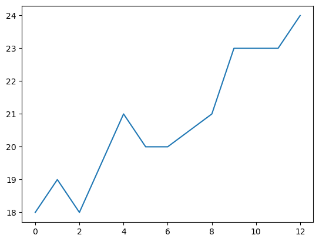

```python
#30 II --> interpolate o bfill
temp.Temperature.interpolate().plot()
```